# Part II - Used Cars Data

## Investigation Overview

> I will just focus on the effect of max_power and km_driven on the selling price of used cars in the dataset. Also, I will be looking into time trends of sale across regions and features of sold cars.

## Dataset Overview

> Based on various market surveys, the consulting firm has gathered a large dataset of different types of used cars across the market. The dataset is madeup of different information about used cars gotten from https://www.kaggle.com/datasets/shubham1kumar/usedcar-data?resource=download.

> The dataset is madeup of 7906 rows and 18 columns in general.

> Data Dictionary:
> - Sales_ID (Sales ID)
> - name (Name of the used car)
> - year (Year of the car purchase)
> - selling_price (Current selling price for used car)
> - km_driven (Total km driven)
> - Region (Region where it is used)
> - State or Province (State or Province where it is used)
> - City (City where it is used)
> - fuel (Fuel type)
> - seller_type (Who is selling the car)
> - transmission (Transmission type of the car)
> - transmission (Transmission type of the car)
> - owner (Owner type)
> - mileage (Mileage of the car)
> - engine (engine power)
> - max_power (max power)
> - seats (Number of seats)
> - sold (used car sold or not)

```python
# import all packages and set plots to be embedded inline
import numpy as np
import pandas as pd
import matplotlib.pyplot as plt
import seaborn as sb

%matplotlib inline

# suppress warnings from final output
import warnings
warnings.simplefilter("ignore")
```

```python
# load the dataset for the project
df = pd.read_csv('./UserCarData.csv')
```

```python
# Extracting dataset of sold cars from the whole dataset
sold_cars = df.query('sold=="Y"')
```

```python
# change variables to category data type
cat_var=['Region','fuel','seller_type', 'transmission', 'sold']
for var in cat_var:
    df[var] = df[var].astype('category')
```

```python
# Change owner to ordered category data type seeing that it is a ordinal qualitative variable
owner_level = ['Fourth_Above_Owner', 'Third_Owner', 'Second_Owner', 'First_Owner', 'Test_Drive_Car']
owner_levels = pd.api.types.CategoricalDtype(categories=owner_level, ordered=True)
df.owner = df.owner.astype(owner_levels)
```

```python
# Functions for various plots
def Hist_bin(data, x, xlabel, ylabel, title, bins):
    import matplotlib.pyplot as plt
    plt.hist(data=data, x=x, bins=bins)
    plt.xlabel(xlabel)
    plt.ylabel(ylabel)
    plt.title(title, loc='center');

def Hist(data, x, xlabel, ylabel, title):
    import matplotlib.pyplot as plt
    plt.hist(data=data, x=x)
    plt.xlabel(xlabel)
    plt.ylabel(ylabel)
    plt.title(title, loc='center');

def Scatter(data, x, y, xlabel, ylabel, title):
    import matplotlib.pyplot as plt
    plt.scatter(data=data, x=x, y=y, alpha=0.2)
    plt.xlabel(xlabel)
    plt.ylabel(ylabel)
    plt.title(title, loc='center');

def violin(data, x, y, title):
    import seaborn as sb
    a = sb.violinplot(data=data, x=x, y=y, inner=None, color=def_color);
    plt.title(title);

def Box(data, x, y, title):
    import seaborn as sb
    a = sb.boxplot(data=data, x=x, y=y, color=def_color);
    plt.title(title);

def Facet(data, col, colwrap, map_func, var1, var2):
    a = sb.FacetGrid(data=data, col=col, col_wrap=colwrap, height=4)
    a.map(map_func, var1, var2)
    a.set_titles('{col_name}');
```

## Distribution of Selling Price of Cars in the Dataset

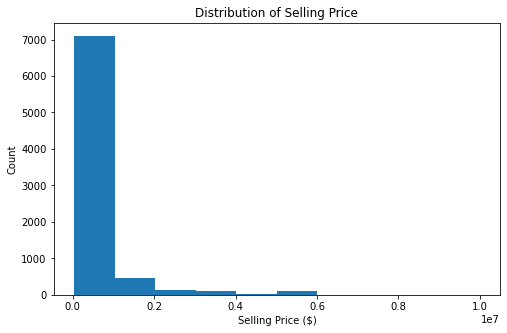

```python
# Distribution of selling price of used cars
plt.figure(figsize=(8,5))
Hist(df, 'selling_price', 'Selling Price ($)', 'Count', 'Distribution of Selling Price')
```

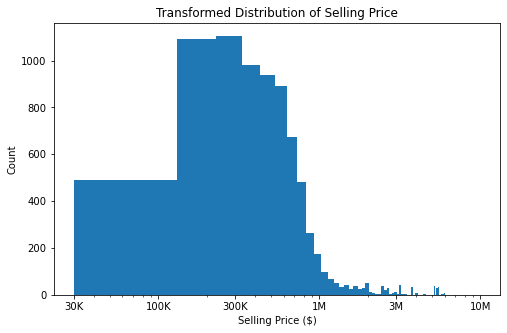

```python
# Transformed distribution of selling price of used cars
bin=np.arange(30000, 10000000, 100000)
plt.figure(figsize=(8,5))
Hist_bin(df, 'selling_price', 'Selling Price ($)', 'Count', 'Transformed Distribution of Selling Price', bins=bin)
plt.xscale('log')
plt.xticks([30000,100000,300000,1000000,3000000,10000000], ['30K','100K','300K','1M','3M','10M']);
```

## Distribution of Km Driven by Cars

> The distribution shows that most of the cars in the dataset has not traveled much distance. The most common km driven by cars is around 50,000 Km.

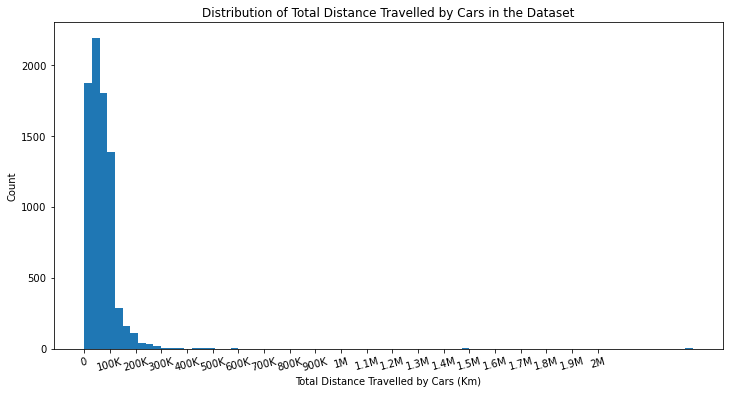

```python
# Distribution of km driven by cars in the dataset
km_bin = np.arange(df.km_driven.min(), df.km_driven.max()+30000, 30000)
xtic = np.arange(0, 2100000, 100000)
plt.figure(figsize=(12,6))
Hist_bin(df, 'km_driven',bins=km_bin, xlabel='Total Distance Travelled by Cars (Km)', ylabel='Count', title='Distribution of Total Distance Travelled by Cars in the Dataset')
plt.xticks(xtic, [0, '100K', '200K', '300K', '400K', '500K', '600K', '700K', '800K', '900K', '1M', '1.1M', '1.2M', '1.3M', '1.4M', '1.5M', '1.6M', '1.7M', '1.8M', '1.9M', '2M'], rotation=15);
```

## Effect of Total Distance Travelled by Cars on Their Selling Price

It was observed that there is a negative correlation between the selling price and km_driven. This implies that an increase in km_driven will lead to a decrease in the selling price.

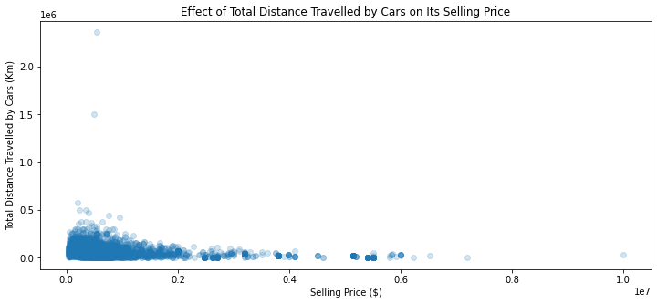

```python
# scatterplot to show the relationship between selling price and km_driven by cars
plt.figure(figsize=(12,5))
Scatter(df, 'selling_price', 'km_driven', xlabel='Selling Price ($)', ylabel='Total Distance Travelled by Cars (Km)', title='Effect of Total Distance Travelled by Cars on Its Selling Price');
```

## Effect of Maximum Power of Cars on Their Selling Price

This shows that there is a strong relationship between the selling price of a car and the max_power of the car i.e. as the max_power of cars increases, the selling price also increase and vice versa.

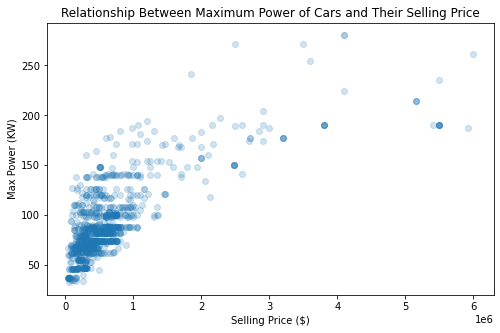

```python
# Scatterplot to show the relationship between selling price and max_power of cars in sample data
sample_data = df.sample(1000)
plt.figure(figsize=(8,5))
Scatter(sample_data, 'selling_price', 'max_power', xlabel='Selling Price ($)', ylabel='Max Power (KW)', title='Relationship Between Maximum Power of Cars and Their Selling Price');
```

## Sales Across Regions

The chart at the left shows that the Southern region has the highest sale in terms of price followed by the West, then East and Central. In terms of the car sold, the chart at the right shows that the East has the highest number of cars sold.

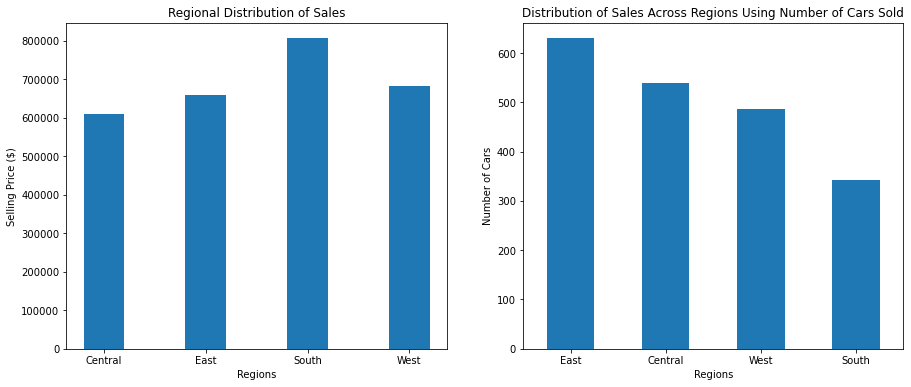

```python
plt.figure(figsize=(15,6))
plt.subplot(1,2,1)
regional_meanprice = sold_cars.groupby('Region').mean()
plt.bar(data=regional_meanprice, height='selling_price', x=regional_meanprice.index, width=0.4);
plt.xlabel('Regions')
plt.ylabel('Selling Price ($)')
plt.title('Regional Distribution of Sales');

plt.subplot(1,2,2)
# Regional distribution of sales in terms of the number of cars
regional_sales = sold_cars.Region.value_counts()
regional_sales.plot(kind='bar')
plt.xticks(rotation=0)
plt.xlabel('Regions')
plt.ylabel('Number of Cars')
plt.title('Distribution of Sales Across Regions Using Number of Cars Sold');
```

## Effect of Seller Types on Sales Across Regions

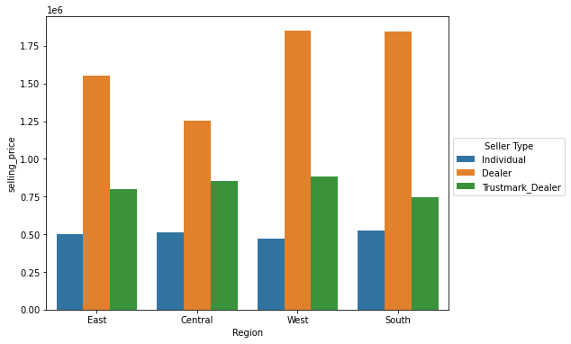

```python
# Relationship between seller type and the selling price across regions
plt.figure(figsize=(8,6))
sb.barplot(data=sold_cars, hue='seller_type', y='selling_price', x='Region', ci=0)
plt.legend(loc='best', bbox_to_anchor=(0.8, 0.1, 0.5, 0.5), title='Seller Type');
```

## Trends in Price of Sold Cars Over the Years

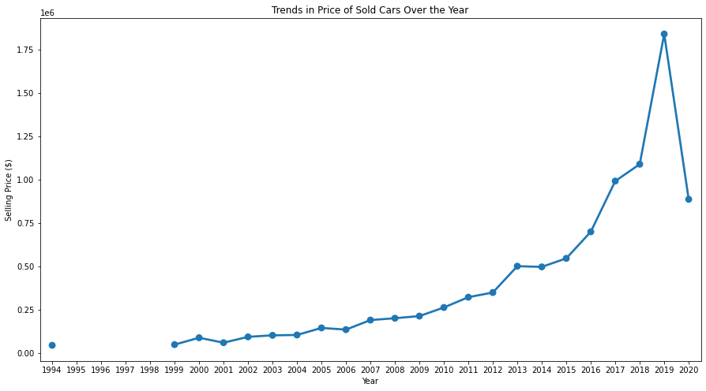

```python
# The trends in price of cars over the year
plt.figure(figsize=(15,8));
sb.pointplot(data=sold_cars, x='year', y='selling_price', order=np.arange(1994,2021,1), linestyles='-', ci=0, dodge=True);
plt.xlabel('Year')
plt.ylabel('Selling Price ($)')
plt.title('Trends in Price of Sold Cars Over the Year');
```

## The Trends in the Price of Sold Cars Over the Years Across Regions

This later strenghten the observation in the trends above. The trends across the region follow the same pattern as the general trend in the price of sold cars.

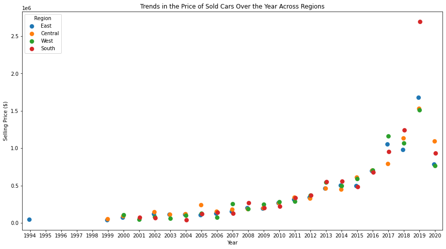

```python
# The trends in price of sold cars over the year across regions
plt.figure(figsize=(15,8));
sb.pointplot(data=sold_cars, x='year', y='selling_price', order=np.arange(1994,2021,1), hue='Region', linestyles='', ci=0, dodge=True);
plt.xlabel('Year')
plt.ylabel('Selling Price ($)')
plt.title('Trends in the Price of Sold Cars Over the Year Across Regions');
```

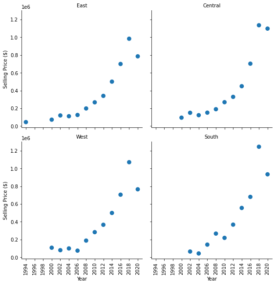

```python
# Faceting the trends in price of cars over the year over region
f = sb.FacetGrid(data=sold_cars, col='Region', col_wrap=2, height=4)
f.map(sb.pointplot, 'year', 'selling_price', order=np.arange(1994,2022,2), linestyles='', ci=0, dodge=True)
f.set_titles('{col_name}')
f.set_xticklabels(rotation=-270)
f.set_xlabels('Year')
f.set_ylabels('Selling Price ($)');
```

```python
# Creating slide-deck for the explanatory visualiz
!jupyter nbconvert Part_II_Used_Cars_Data.ipynb --to slides --post serve --no-input --no-prompt
```